# Análisis de Subdimensiones NPI

Natalia Santis

2025-05-19

## 1. Librerías necesarias

```r
#install.packages("tidyverse")
library(tidyverse) #manipulación de datos
#install.packages("psych")
library(psych)  # análisis factorial y análisis paralelo
library(GPArotation)    # rotaciones oblicuas
#install.packages("emmeans")
library(emmeans)        # pruebas post-hoc (8.2)
#install.packages("rstatix")
library(rstatix)  # evauacion de supuesto anova (8.3)
#install.packages("ggpubr")
library(ggpubr) #para ggplot 11.1
library(broom) # resultados paramétricos 11.3
library(writexl)
```

## 2. Carga de datos

## 3. Conteo de sujetos por grupo

```
## # A tibble: 3 × 2
##   Grupo     N
##   <chr> <int>
## 1 AD      235
## 2 NC      262
## 3 bvFTD    49
```

## 4. Verificar diferencias demográficas

En este bloque comprobamos si las variables demográficas clave (**edad**, **años de escolaridad** y **sexo**) difieren entre los grupos clínicos (AD, bvFTD y NC). Los resultados nos indican si es necesario ajustar los ítems del NPI por estas covariables antes de proceder al análisis factorial (p<0.005)

```r
# ANOVA para edad
demo_age_aov <- aov(demo_age ~ clinical_diagnosis, data = data_limpia2)
print(summary(demo_age_aov))
```

```
##                     Df Sum Sq Mean Sq F value Pr(>F)
## clinical_diagnosis   2  20092   10046   113.6 <2e-16 ***
## Residuals          543  48034      88
## ---
## Signif. codes:  0 '***' 0.001 '**' 0.01 '*' 0.05 '.' 0.1 ' ' 1
```

```r
# ANOVA para escolaridad (cog_ed)
demo_edu_aov <- aov(cog_ed ~ clinical_diagnosis, data = data_limpia2)
print(summary(demo_edu_aov))
```

```
##                     Df Sum Sq Mean Sq F value Pr(>F)
## clinical_diagnosis   2   1849   924.3   40.76 <2e-16 ***
## Residuals          543  12314    22.7
## ---
## Signif. codes:  0 '***' 0.001 '**' 0.01 '*' 0.05 '.' 0.1 ' ' 1
```

```r
# Distribución de sexo (chi-cuadrado)
tabla_sexo <- table(data_limpia2$demo_sex, data_limpia2$clinical_diagnosis)
print(tabla_sexo)
```

```
##
##      AD  CN FTD
##   1 143 186  23
##   2  92  76  26
```

```r
sexo_chi <- chisq.test(tabla_sexo)
print(sexo_chi)
```

```
##
##  Pearson's Chi-squared test
##
## data:  tabla_sexo
## X-squared = 12.784, df = 2, p-value = 0.001675
```

## 5. Residualizar ítems NPI por edad,educación y sexo

Antes de estandarizar y hacer el análisis factorial, eliminamos la varianza atribuible a las covariables demográficas (**edad**, **escolaridad** y **sexo**). En este paso usamos un modelo lineal para cada ítem `npi_...sev` y extraemos sus **residuales**, los cuales representan la parte de la severidad libre de estos efectos demográficos.

```r
# Selección de ítems de severidad NPI
npi_vars <- names(data_limpia2) %>% str_subset("^npi_.*sev$")

# Residualizar por edad, escolaridad y sexo
data_resid <- data_limpia2 %>%
  mutate(across(
    all_of(npi_vars),
    ~ resid(lm(.x ~ demo_age + cog_ed + demo_sex, data = data_limpia2, na.action = na.exclude))# Usar na.action = na.exclude para que los residuales tengan longitud igual al dataset original (quita lo NA para el calculo y despues los regresa a su posición)
  ))
```

### 5.1 Verificación de residualización

Para comprobar que la residualización eliminó correctamente la varianza demográfica se hizo:

1. Revisar una muestra de valores originales vs. residuales.
2. Comprobar que los residuales estén descorrelacionados con edad, escolaridad y sexo.

```
## # A tibble: 10 × 2
##    original residual
##       <dbl>    <dbl>
##  1        0  -0.219
##  2        0  -0.342
##  3        0  -0.0340
##  4        0  -0.219
##  5        0  -0.335
##  6        0  -0.275
##  7        2   1.82
##  8        0  -0.182
##  9        0  -0.335
## 10        2   1.85
```

```
## Correl residual-edad: 0
```

```
## Correl residual-esc: 0
```

```
##                        Df Sum Sq Mean Sq F value Pr(>F)
## data_limpia2$demo_sex   1    0.0  0.0000       0      1
## Residuals             544  224.9  0.4134
```

## 6. Estandarizar residuos (z-scores ocupando la media y SD de los CN)

Se convierten los residuos a puntajes z para asegurar comparabilidad de escalas.

```r
# 1) Calcula medias y ds sólo en controles
controls <- data_resid %>% filter(clinical_diagnosis == "CN")

# Vector de ítems NPI
npi_vars <- names(data_resid) %>% str_subset("^npi_.*sev$")

# 2) Saca medias y ds de controles
ctrl_stats <- controls %>%
  summarise(across(all_of(npi_vars),
                   list(mean = ~ mean(.x, na.rm=TRUE),
                        sd   = ~ sd(.x,   na.rm=TRUE)),
                   .names = "{.col}_{.fn}"))

# 3) Aplica el z-score basado en ctrl_stats
data_z <- data_resid %>%
  mutate(across(
    all_of(npi_vars),
    ~ (.x - ctrl_stats[[paste0(cur_column(), "_mean")]]) /
       ctrl_stats[[paste0(cur_column(), "_sd")]]
  ))

# Comprueba
head(select(data_z, all_of(npi_vars)), 10)
```

```
## # A tibble: 10 × 12
##    npi_delsev npi_hallsev npi_agitsev npi_depdsev npi_anxsev npi_elatsev
##         <dbl>       <dbl>       <dbl>       <dbl>      <dbl>       <dbl>
##  1     -0.596     -1.27        -0.376     -0.176      -0.348      -0.400
##  2     -1.74      -2.08         3.26      -0.531       0.985      -0.783
##  3      1.12       0.842        0.437     -0.0654     -0.154       0.372
##  4     -0.600     -0.0703      -0.479      2.94        2.48       -0.233
##  5     -1.66      -2.06         7.49       1.32        1.01       -0.756
##  6     -1.11      -0.399       11.8        4.58        3.90       -0.409
##  7     18.2       -0.524        3.81       3.38       -0.528      -0.344
##  8     -0.257      0.0574      -0.279     -0.555      -0.472      -0.107
##  9     -1.67      -1.78        -0.965      3.04        0.887      -0.784
## 10     18.5       23.3         12.4        4.97        2.61        7.00
## # ℹ 6 more variables: npi_apasev <dbl>, npi_disnsev <dbl>, npi_irrsev <dbl>,
## #   npi_motsev <dbl>, npi_nitesev <dbl>, npi_appsev <dbl>
```

## 7. Pruebas de adecuación factorial

En esta sección evaluamos si los ítems residualizados cumplen los requisitos para un análisis factorial:

- **Prueba de Bartlett** de esfericidad: verifica que la matriz de correlaciones difiera significativamente de una matriz identidad (p < 0.05).
- **Índice Kaiser-Meyer-Olkin (KMO)**: mide la adecuación de muestreo (valores > 0.6 aceptables, > 0.8 muy buenos).

```r
# Matriz de correlaciones
datum <- data_z[npi_vars]
cormat <- cor(datum, use = "pairwise.complete.obs")
print(cormat) # muestra que califica para analisis factorial (0.3 < r < 0.8)
```

```
##             npi_delsev npi_hallsev npi_agitsev npi_depdsev npi_anxsev
## npi_delsev   1.0000000   0.4074087   0.5188100   0.2239925  0.2208774
## npi_hallsev  0.4074087   1.0000000   0.2705980   0.1528198  0.2134073
## npi_agitsev  0.5188100   0.2705980   1.0000000   0.3280814  0.3886583
## npi_depdsev  0.2239925   0.1528198   0.3280814   1.0000000  0.4195978
## npi_anxsev   0.2208774   0.2134073   0.3886583   0.4195978  1.0000000
## npi_elatsev  0.1844199   0.1605725   0.4394093   0.1586067  0.2396582
## npi_apasev   0.2485403   0.2115201   0.3636463   0.3673468  0.3721607
## npi_disnsev  0.4296621   0.3084853   0.4882968   0.3070854  0.2736013
## npi_irrsev   0.4212977   0.2853723   0.5961754   0.3835084  0.4281631
## npi_motsev   0.2869611   0.2419211   0.3364918   0.2537999  0.3409185
## npi_nitesev  0.1884991   0.1680459   0.2989271   0.2125595  0.2453288
## npi_appsev   0.2526602   0.2178882   0.2988165   0.2488555  0.2355849
##             npi_elatsev npi_apasev npi_disnsev npi_irrsev npi_motsev
## npi_delsev    0.1844199  0.2485403   0.4296621  0.4212977  0.2869611
## npi_hallsev   0.1605725  0.2115201   0.3084853  0.2853723  0.2419211
## npi_agitsev   0.4394093  0.3636463   0.4882968  0.5961754  0.3364918
## npi_depdsev   0.1586067  0.3673468   0.3070854  0.3835084  0.2537999
## npi_anxsev    0.2396582  0.3721607   0.2736013  0.4281631  0.3409185
## npi_elatsev   1.0000000  0.2065183   0.3433801  0.3868541  0.1886367
## npi_apasev    0.2065183  1.0000000   0.3656072  0.3556128  0.4353253
## npi_disnsev   0.3433801  0.3656072   1.0000000  0.4807822  0.4079975
## npi_irrsev    0.3868541  0.3556128   0.4807822  1.0000000  0.3297031
## npi_motsev    0.1886367  0.4353253   0.4079975  0.3297031  1.0000000
## npi_nitesev   0.1105027  0.3210451   0.2227013  0.3119510  0.2566938
## npi_appsev    0.2198495  0.4368007   0.3794520  0.3657022  0.3353261
##             npi_nitesev npi_appsev
## npi_delsev    0.1884991  0.2526602
## npi_hallsev   0.1680459  0.2178882
## npi_agitsev   0.2989271  0.2988165
## npi_depdsev   0.2125595  0.2488555
## npi_anxsev    0.2453288  0.2355849
## npi_elatsev   0.1105027  0.2198495
## npi_apasev    0.3210451  0.4368007
## npi_disnsev   0.2227013  0.3794520
## npi_irrsev    0.3119510  0.3657022
## npi_motsev    0.2566938  0.3353261
## npi_nitesev   1.0000000  0.4314105
## npi_appsev    0.4314105  1.0000000
```

```r
# 1) Prueba de Bartlett
bartlett_res <- cortest.bartlett(cormat, n = nrow(datum))
print(bartlett_res)
```

```
## $chisq
## [1] 1862.617
##
## $p.value
## [1] 0
##
## $df
## [1] 66
```

```r
# 2) KMO
kmo_res <- KMO(datum)
print(kmo_res)
```

```
## Kaiser-Meyer-Olkin factor adequacy
## Call: KMO(r = datum)
## Overall MSA =  0.88
## MSA for each item =
##  npi_delsev npi_hallsev npi_agitsev npi_depdsev  npi_anxsev npi_elatsev
##        0.83        0.87        0.86        0.89        0.88        0.84
##  npi_apasev npi_disnsev  npi_irrsev  npi_motsev npi_nitesev  npi_appsev
##        0.89        0.91        0.91        0.91        0.85        0.86
```

**Interpretación de resultados:**

**Prueba de Bartlett:** χ²(66) = **1862.6166973** (df = **66**), p = **0**. Este resultado significativo indica que la matriz de correlaciones **no** es una matriz identidad, lo que confirma que existe suficiente correlación entre los ítems para justificar un análisis factorial.

**Índice KMO:** El valor global de MSA = **0.88**, se considera *muy bueno*, por encima del umbral de 0.80. Además, los valores individuales de MSA para cada ítem (rango 0.83–0.91) superan el criterio mínimo de 0.60, lo que muestra que cada ítem aporta adecuadamente a la factorización.

En conjunto, estos indicadores confirman que los datos son apropiados para proseguir con el análisis paralelo (siguiente sección) y la Extracción Factorial Exploratoria.

## 8. Determinar número de factores (Análisis paralelo)

Se usa `fa.parallel()` para comparar los eigenvalores reales con los de matrices aleatorias y decidir cuántos factores extraer.

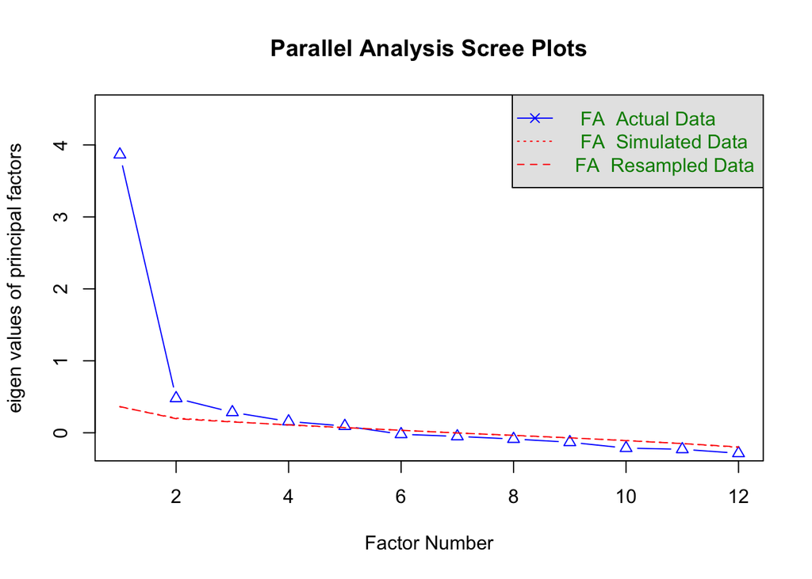

```
## Parallel analysis suggests that the number of factors =  4  and the number of components =  NA
```

```r
fa.parallel(
  datum,
  fm = "pa", # factorización por ejes principales
  fa = "fa", # comparación los eigenvalores reales contra los de un modelo factorial
  n.iter = 100 # iteraciones
)
```

```r
nf <- 4  # usar el valor sugerido por fa.parallel
```

**Interpretación del análisis paralelo:** El resultado indica que **el número óptimo de factores es 4** (según fa.parallel, aquel donde el eigenvalor real supera al de los datos simulados).. Esto significa que, tras ajustar por edad, escolaridad y sexo y estandarizar los residuos, cuatro factores principales capturan la estructura subyacente de las variables de severidad del NPI, superando a los eigenvalores esperados bajo aleatoriedad.

## 9. Análisis Factorial Exploratorio

Con el número de factores `nf` sugerido:

```r
nf <- 4  # usar el valor sugerido por fa.parallel
ef <- fa(
  datum,           # la matriz de datos (z-scores de los ítems NPI)
  nfactors = nf,   # número de factores
  fm = "pa",       # método de estimación: principal axis factoring (ejes principales)
  rotate = "oblimin"  # rotación oblicua para permitir factores correlacionados
)
print(ef, digits = 2)
```

```
## Factor Analysis using method =  pa
## Call: fa(r = datum, nfactors = nf, rotate = "oblimin", fm = "pa")
## Standardized loadings (pattern matrix) based upon correlation matrix
##               PA4   PA3   PA1   PA2   h2   u2 com
## npi_delsev  -0.02 -0.01  0.00  0.91 0.80 0.20 1.0
## npi_hallsev  0.06  0.11  0.02  0.38 0.23 0.77 1.2
## npi_agitsev  0.15  0.01  0.55  0.24 0.63 0.37 1.5
## npi_depdsev  0.57  0.03  0.01  0.02 0.35 0.65 1.0
## npi_anxsev   0.69 -0.05  0.08 -0.03 0.49 0.51 1.0
## npi_elatsev -0.06  0.02  0.70 -0.11 0.40 0.60 1.1
## npi_apasev   0.40  0.40 -0.04  0.02 0.45 0.55 2.0
## npi_disnsev  0.07  0.23  0.32  0.24 0.45 0.55 2.9
## npi_irrsev   0.25  0.09  0.45  0.13 0.56 0.44 1.8
## npi_motsev   0.30  0.28  0.00  0.13 0.33 0.67 2.4
## npi_nitesev  0.14  0.44 -0.01  0.02 0.28 0.72 1.2
## npi_appsev  -0.05  0.80  0.04  0.00 0.62 0.38 1.0
##
##                        PA4  PA3  PA1  PA2
## SS loadings           1.48 1.40 1.37 1.33
## Proportion Var        0.12 0.12 0.11 0.11
## Cumulative Var        0.12 0.24 0.35 0.47
## Proportion Explained  0.26 0.25 0.25 0.24
## Cumulative Proportion 0.26 0.52 0.76 1.00
##
##  With factor correlations of
##      PA4  PA3  PA1  PA2
## PA4 1.00 0.49 0.54 0.40
## PA3 0.49 1.00 0.43 0.36
## PA1 0.54 0.43 1.00 0.50
## PA2 0.40 0.36 0.50 1.00
##
## Mean item complexity =  1.5
## Test of the hypothesis that 4 factors are sufficient.
##
## df null model =  66  with the objective function =  3.45 with Chi Square =  1862.62
## df of  the model are 24  and the objective function was  0.11
##
## The root mean square of the residuals (RMSR) is  0.02
## The df corrected root mean square of the residuals is  0.04
##
## The harmonic n.obs is  545 with the empirical chi square  39.23  with prob <  0.026
## The total n.obs was  546  with Likelihood Chi Square =  59.88  with prob <  6.6e-05
##
## Tucker Lewis Index of factoring reliability =  0.945
## RMSEA index =  0.052  and the 90 % confidence intervals are  0.036 0.069
## BIC =  -91.38
## Fit based upon off diagonal values = 0.99
## Measures of factor score adequacy
##                                                    PA4  PA3  PA1  PA2
## Correlation of (regression) scores with factors   0.86 0.86 0.86 0.91
## Multiple R square of scores with factors          0.73 0.75 0.75 0.83
## Minimum correlation of possible factor scores     0.47 0.49 0.49 0.66
```

**Interpretación de la EFA:**

- **SS loadings y Varianza explicada:** los cuatro factores extraídos tienen cargas propias (SS loadings) de 1.48, 1.40, 1.37 y 1.33, que corresponden al 12%, 12%, 11% y 11% de la varianza total de los ítems, sumando un 47% acumulado. Cada factor aporta de manera balanceada (proporción dentro de la varianza explicada por los factores, Proportion Explained ≈24–26%).
- **Correlaciones entre factores:** todos los factores presentan correlaciones moderadas (r = 0.36–0.54), justificando el uso de rotación oblicua (oblimin) que permite factores correlacionados.
- **Ajuste del modelo:**
  - **RMSR** = **0.02** (muy cercano a 0) indica excelentes ajustes entre la matriz observada y la recreada.
  - **RMSEA** = **0.052** (IC 90%: **0.036**–**0.069**) sugiere buen ajuste (valores <0.06 aceptables).
  - **TLI** = 0.945, cercano a 1, denota alta fiabilidad factorial.
  - El test χ² del modelo (df=24, χ²=59.88, p<.001) y el χ² empírico (39.23, p<.026) indican un ajuste significativo, pero con alta potencia (>500 datos) esto es esperable.
- **Comunalidades (h2) y unicidades (u2):**
  - Las comunalidades (h2) oscilan entre ~0.23 y 0.80, mostrando que la mayoría de ítems están bien representados por los cuatro factores.
  - Las unicidades (u2 = 1 – h2) reflejan la varianza única o error.
  - La complejidad media de ítems = 1.5 sugiere que la mayoría carga predominantemente en un solo factor.

En conjunto, estos indicadores confirman que un modelo de 4 factores es apropiado y ofrece un buen ajuste a los datos residualizados y estandarizados.

## 10. Obtener puntuaciones y compuestos

Tras el EFA, se extraen las puntuaciones factoriales y se construyen compuestos

```r
# 1) Puntuaciones factoriales
efa_scores <- as_tibble(ef$scores)
colnames(efa_scores) <- paste0("Factor", seq_len(ncol(efa_scores)))

# 2) Unir con datos originales
data_scores <- bind_cols(data_limpia2, efa_scores)

# 3) Compuestos para cada factor basado en cargas > 0.30
L <- as.data.frame(unclass(ef$loadings[]))
composite_list <- list()
for(i in seq_len(ncol(L))) {
  factor_name <- paste0("Factor", i)
  # Seleccionamos solo aquellos ítems cuya carga absoluta supere el umbral:
  items_i <- rownames(L)[abs(L[,i]) > 0.30]
  comp_col <- paste0("comp_", factor_name)
  # Promediamos los z-scores de los ítems seleccionados para obtener el compuesto
  data_scores[[comp_col]] <- rowMeans(select(data_z, all_of(items_i)), na.rm = TRUE)
  composite_list[[factor_name]] <- items_i
}
```

### 10.1 Mostrar resultados

```
## $Factor1
## [1] "npi_depdsev" "npi_anxsev"  "npi_apasev"
##
## $Factor2
## [1] "npi_apasev"  "npi_nitesev" "npi_appsev"
##
## $Factor3
## [1] "npi_agitsev" "npi_elatsev" "npi_disnsev" "npi_irrsev"
##
## $Factor4
## [1] "npi_delsev"  "npi_hallsev"
```

A partir de los ítems que cargan en cada factor (|carga| > 0.30), se propone la siguiente interpretación conceptual:

- **Factor 1: Afecto depresivo y ansiedad**
  - Ítems: `npi_depdsev` (depresión), `npi_anxsev` (ansiedad), `npi_apasev` (apatía).
  - Este factor agrupa síntomas del estado de ánimo y motivación, reflejando un componente afectivo-primer orden.
- **Factor 2: Alteraciones de sueño y apetito**
  - Ítems: `npi_apasev` (apatía), `npi_nitesev` (insomnio/nocturnidad), `npi_appsev` (cambios de apetito).
  - Representa cambios en los patrones básicos de sueño y alimentación, a menudo asociados con desregulación afectiva.
- **Factor 3: Agitación y desinhibición**
  - Ítems: `npi_agitsev` (agitación), `npi_elatsev` (euforia), `npi_disnsev` (desinhibición), `npi_irrsev` (irritabilidad).
  - Refleja un núcleo de conductas exteriorizadas y de control inhibitorio alterado.
- **Factor 4: Sintomatología psicótica**
  - Ítems: `npi_delsev` (delirios), `npi_hallsev` (alucinaciones).
  - Agrega las manifestaciones de psicosis, indicando un dominio separado de pensamiento y percepción.

Estas etiquetas facilitan la interpretación clínica de cada dimensión factorial y permiten explorar cómo difieren entre grupos (NC, AD, bvFTD) en pasos posteriores.

### 10.2 Consistencia interna: Cronbach’s Alpha

```r
cronbach_res <- map_df(names(composite_list), function(fac) {
  items <- composite_list[[fac]]
  # extraemos la submatriz de z-scores para esos ítems
  dat_fac <- select(data_z, all_of(items))
  # calculamos alfa
  a <- psych::alpha(dat_fac, warnings = FALSE)
  tibble(
    Factor       = fac,
    Alpha        = round(a$total$raw_alpha, 2),
    `# ítems`    = length(items),
    `Ítems`      = paste(items, collapse = ", ")
  )
})

cronbach_res
```

```
## # A tibble: 4 × 4
##   Factor  Alpha `# ítems` Ítems
##   <chr>   <dbl>     <int> <chr>
## 1 Factor1  0.64         3 npi_depdsev, npi_anxsev, npi_apasev
## 2 Factor2  0.66         3 npi_apasev, npi_nitesev, npi_appsev
## 3 Factor3  0.73         4 npi_agitsev, npi_elatsev, npi_disnsev, npi_irrsev
## 4 Factor4  0.55         2 npi_delsev, npi_hallsev
```

La severidad de los síntomas neuropsiquiátricos (NPI-Q) fue sometida a un Análisis Factorial Exploratorio (AFE) con extracción por ejes principales (principal axis factoring) y rotación oblicua (Oblimin). El objetivo fue identificar subescalas clínicas coherentes y evaluar su consistencia interna mediante alfa de Cronbach. Se retuvieron cuatro factores, de acuerdo al criterio de análisis paralelo (fa.parallel).

Factor 1 (Afecto depresivo/ansiedad) agrupó tres ítems relacionados con el estado de ánimo: depresión, ansiedad y apatía. Su consistencia interna fue aceptable (α = **0.64**)).

Factor 2 (Sueño y apetito) combinó apatía (nuevamente), alteraciones del sueño y cambios en el apetito, reflejando desregulación de patrones básicos de descanso y alimentación (α = **0.66**).

Factor 3 (Agitación/desinhibición) incluyó agitación motora, euforia, desinhibición e irritabilidad, configurando un núcleo de conductas exteriorizadas (α = **0.73**).

Factor 4 (Sintomatología psicótica) reunió delirios y alucinaciones, correspondientes al dominio psicótico (α = **0.55**).

Estos cuatro factores explican conjuntamente el 47 % de la varianza total de los ítems y muestran un ajuste adecuado (RMSR = 0.02; RMSEA = 0.052 [IC 90 %: 0.036–0.069]; TLI = 0.945). La aplicación de rotación oblicua (Oblimin) permitió captar las correlaciones moderadas observadas entre factores (r = 0.36–0.54), preservando la estructura subyacente de los síntomas neuropsiquiátricos.

## 11. Comparación Paramétrica de puntuaciones factoriales entre grupos

Para evaluar diferencias en las dimensiones identificadas (Factor1–Factor4) entre los grupos clínicos (AD, bvFTD, NC):

### 11.1 Gráficos y ANOVA global

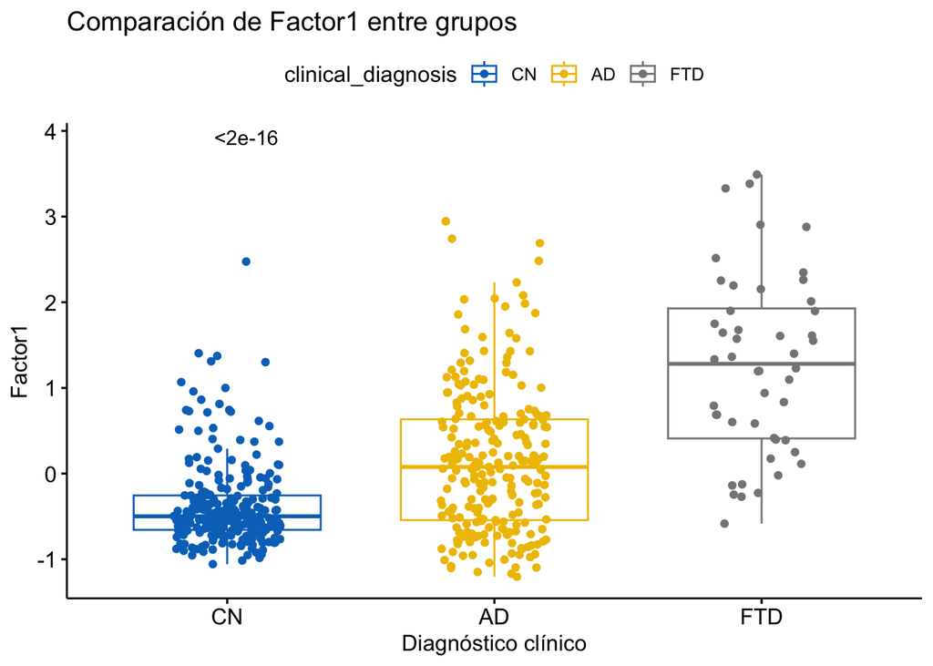

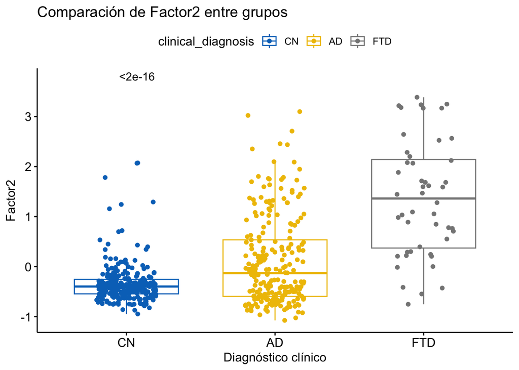

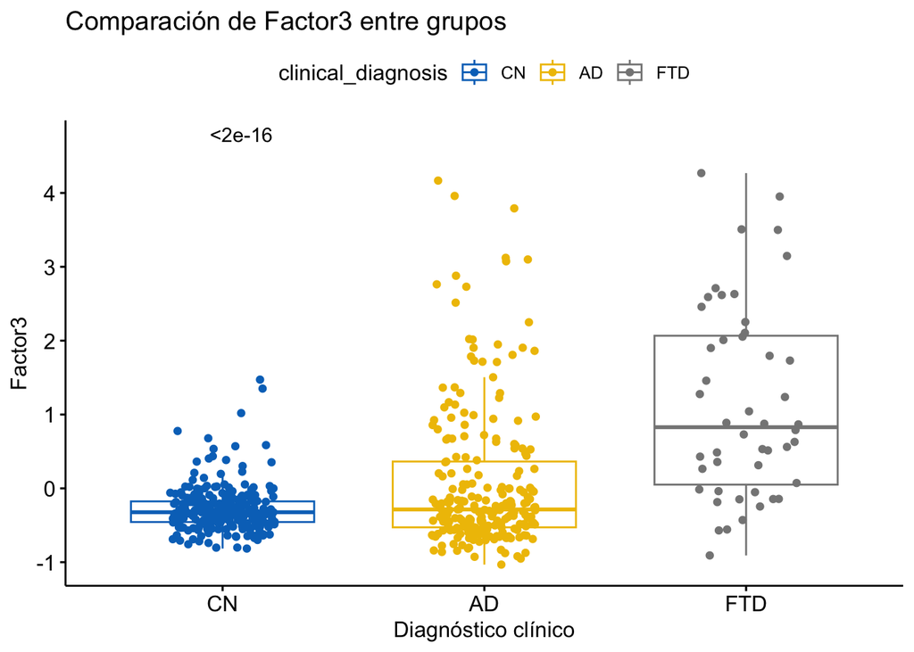

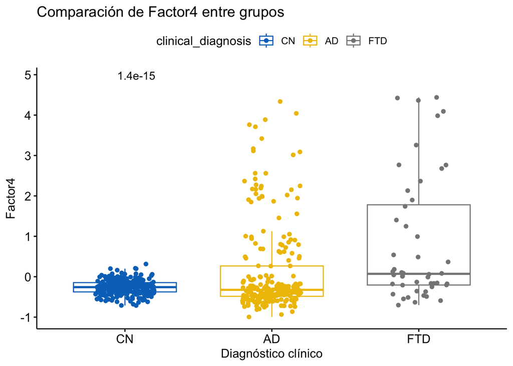

[output not shown]

A partir de los boxplots y los valores p del ANOVA para cada factor:

En conjunto, estos resultados muestran que en las cuatro dimensiones factoriales existe un aumento progresivo de la severidad de los síntomas (capturados por los factores) desde NC, pasando por AD, hasta bvFTD. Esto sugiere que cada factor discrimina eficazmente entre los grupos clínicos.

#### 11.1.2 Tabla para ver missing

```
## # A tibble: 12 × 5
##    factor  clinical_diagnosis total complete missing
##    <chr>   <fct>              <int>    <int>   <int>
##  1 Factor1 CN                   262      261       1
##  2 Factor1 AD                   235      233       2
##  3 Factor1 FTD                   49       48       1
##  4 Factor2 CN                   262      261       1
##  5 Factor2 AD                   235      233       2
##  6 Factor2 FTD                   49       48       1
##  7 Factor3 CN                   262      261       1
##  8 Factor3 AD                   235      233       2
##  9 Factor3 FTD                   49       48       1
## 10 Factor4 CN                   262      261       1
## 11 Factor4 AD                   235      233       2
## 12 Factor4 FTD                   49       48       1
```

```
## # A tibble: 4 × 2
##   record_id clinical_diagnosis
##   <chr>     <chr>
## 1 AF244     AD
## 2 BN00185   AD
## 3 RE008     FTD
## 4 TA0082    CN
```

### 11.2 Pruebas Tukey post-hoc entre grupos

Para identificar **qué pares** de grupos difieren en cada factor después del ANOVA, realizamos comparaciones múltiples de Tukey:

```
## $Factor1
##  contrast   estimate         SE  df t.ratio p.value
##  CN - AD  -0.5174974 0.06475711 539  -7.991  <.0001
##  CN - FTD -1.6393243 0.11283935 539 -14.528  <.0001
##  AD - FTD -1.1218269 0.11388769 539  -9.850  <.0001
##
## P value adjustment: tukey method for comparing a family of 3 estimates
##
## $Factor2
##  contrast   estimate         SE  df t.ratio p.value
##  CN - AD  -0.4380638 0.06549466 539  -6.689  <.0001
##  CN - FTD -1.7010005 0.11412454 539 -14.905  <.0001
##  AD - FTD -1.2629367 0.11518482 539 -10.964  <.0001
##
## P value adjustment: tukey method for comparing a family of 3 estimates
##
## $Factor3
##  contrast   estimate         SE  df t.ratio p.value
##  CN - AD  -0.3489455 0.06957113 539  -5.016  <.0001
##  CN - FTD -1.4220865 0.12122779 539 -11.731  <.0001
##  AD - FTD -1.0731410 0.12235406 539  -8.771  <.0001
##
## P value adjustment: tukey method for comparing a family of 3 estimates
##
## $Factor4
##  contrast   estimate         SE  df t.ratio p.value
##  CN - AD  -0.3802678 0.07750556 539  -4.906  <.0001
##  CN - FTD -1.0880919 0.13505354 539  -8.057  <.0001
##  AD - FTD -0.7078241 0.13630827 539  -5.193  <.0001
##
## P value adjustment: tukey method for comparing a family of 3 estimates
```

**Interpretación global:**

En resumen, hay un **gradiente consistente** NC < AD < bvFTD en todas las dimensiones factoriales, confirmando que cada factor discrimina de forma clara y estadísticamente significativa entre los tres grupos clínicos.

### 11.3 Tabla de resultados paramétricos

```
## # A tibble: 4 × 4
##   Factor     df `F value` `p value`
##   <chr>   <dbl>     <dbl>     <dbl>
## 1 Factor1     2     114.   3.83e-42
## 2 Factor2     2     115.   2.78e-42
## 3 Factor3     2      70.6  5.71e-28
## 4 Factor4     2      36.5  1.40e-15
```

```
## # A tibble: 12 × 6
##    Factor  Comparison Estimate     SE    df `p adj.`
##    <chr>   <chr>         <dbl>  <dbl> <dbl>    <dbl>
##  1 Factor1 CN - AD      -0.517 0.0648   539 3.55e-10
##  2 Factor1 CN - FTD     -1.64  0.113    539 3.55e-10
##  3 Factor1 AD - FTD     -1.12  0.114    539 3.55e-10
##  4 Factor2 CN - AD      -0.438 0.0655   539 5.24e-10
##  5 Factor2 CN - FTD     -1.70  0.114    539 3.55e-10
##  6 Factor2 AD - FTD     -1.26  0.115    539 3.55e-10
##  7 Factor3 CN - AD      -0.349 0.0696   539 2.15e- 6
##  8 Factor3 CN - FTD     -1.42  0.121    539 3.55e-10
##  9 Factor3 AD - FTD     -1.07  0.122    539 3.55e-10
## 10 Factor4 CN - AD      -0.380 0.0775   539 3.68e- 6
## 11 Factor4 CN - FTD     -1.09  0.135    539 3.55e-10
## 12 Factor4 AD - FTD     -0.708 0.136    539 8.80e- 7
```

### 11.4 Evaluación de supuestos (normalidad y homocedasticidad de los residuos)

```
## # A tibble: 4 × 5
##   Factor  Shapiro_W Shapiro_p Levene_F Levene_p
##   <chr>       <dbl>     <dbl>    <dbl>    <dbl>
## 1 Factor1     0.949  9.70e-13     49.6 1.66e-20
## 2 Factor2     0.915  6.73e-17     76.6 5.24e-30
## 3 Factor3     0.834  2.49e-23     53.7 5.29e-22
## 4 Factor4     0.769  6.39e-27     47.6 9.20e-20
```

Normalidad de residuos (Shapiro–Wilk): Los estadísticos W se alejan de 1, y sus correspondientes p < .05 indican que en los cuatro factores los residuos no siguen una distribución normal.

Homogeneidad de varianzas (Levene): Los valores F son elevados y todas las pruebas arrojan p ≪ .001, lo que revela heterogeneidad de varianzas entre los grupos clínicos.

Dado que se incumplen ambos supuestos (normalidad y homocedasticidad), en lugar de ANOVA+Tukey para las comparaciones de grupos se optará por Kruskal–Wallis seguido de Dunn con corrección Bonferroni.

## 12. Comparación no paramétrica

Si **shapiro_p < .05** o **levene_p < .05**, por tanto se usa Kruskal-Wallis y Dunn:

```
## # A tibble: 4 × 4
##   Factor  `χ² (KW)` `df (KW)` `p-value (KW)`
##   <chr>       <dbl>     <int>          <dbl>
## 1 Factor1     122.          2       3.12e-27
## 2 Factor2      89.4         2       3.78e-20
## 3 Factor3      61.5         2       4.48e-14
## 4 Factor4      26.9         2       1.47e- 6
```

```
## # A tibble: 12 × 5
##    Factor  Comparison statistic `p adj.` signif
##    <chr>   <chr>          <dbl>    <dbl> <chr>
##  1 Factor1 CN vs AD        7.04 5.86e-12 ****
##  2 Factor1 CN vs FTD      10.1  1.59e-23 ****
##  3 Factor1 AD vs FTD       6.01 5.60e- 9 ****
##  4 Factor2 CN vs AD        4.20 7.91e- 5 ****
##  5 Factor2 CN vs FTD       9.29 4.47e-20 ****
##  6 Factor2 AD vs FTD       6.82 2.76e-11 ****
##  7 Factor3 CN vs AD        1.87 1.84e- 1 ns
##  8 Factor3 CN vs FTD       7.84 1.39e-14 ****
##  9 Factor3 AD vs FTD       6.70 6.23e-11 ****
## 10 Factor4 CN vs AD       -1.23 6.53e- 1 ns
## 11 Factor4 CN vs FTD       4.51 1.93e- 5 ****
## 12 Factor4 AD vs FTD       5.17 6.97e- 7 ****
```

Tras la evaluación de supuestos, observamos que todos los factores presentaron p < .05 en la prueba de Kruskal–Wallis, por lo que procedimos con comparaciones de Dunn con corrección de Bonferroni:

  Indica que la sintomatología psicótica (Factor 4) está elevada en bvFTD, pero no en AD comparado con controles.

Estas conclusiones complementan el ANOVA global y muestran un patrón más matizado: mientras que los factores 1 y 2 discriminan todos los pares de grupos, los factores 3 y 4 distinguen principalmente bvFTD de AD y de NC.